# rnaseq assign

brian

2023-11-08

# Libraries

Packages for use in the assignment

```r
library(dplyr)
library(biomaRt)
library(tximport)
library(rhdf5)
library(gplots)
library(org.Hs.eg.db)
library(DESeq2)
library(DT)
library(apeglm)
library(RColorBrewer)
library(IHW)
library(PCAtools)
library(pheatmap)
library(clusterProfiler)
library(EnhancedVolcano)
library(ComplexHeatmap)
library(circlize)
library(fgsea)
library(tidyverse)
library(ggpubr)
```

# Introduction

This R markdown document walks through an RNA-Seq differential expression analysis using `DESeq2` for MA5111. Quality control plots, differential expression results, plots and pathway analysis are covered in the document.

```r
quant_dir <- "/home/rstudio"
list.files(quant_dir)
```

```
##  [1] "c6.all.v2023.2.Hs.symbols.gmt"   "control_1.fastq.gz"
##  [3] "control_2.fastq.gz"              "control_3.fastq.gz"
##  [5] "control1"                        "control2"
##  [7] "control3"                        "Homo_sapiens.GRCh38.cdna.all.fa"
##  [9] "log2_counts.txt"                 "normalised_counts.txt"
## [11] "rnaseq assign.Rmd"               "rnaseq_data.csv"
## [13] "rnaseq-assign.html"              "rnaseq-assign.Rmd"
## [15] "transcriptome_index.fasta"       "tumour_1.fastq.gz"
## [17] "tumour_2.fastq.gz"               "tumour_3.fastq.gz"
## [19] "tumour1"                         "tumour2"
## [21] "tumour3"
```

# Reading Input Data

### Metadata

Read in the file `samples.csv` which contains the experimental metadata. Please make sure that the rownames of this dataframe match the kallisto quantification directory names at `/home/rnaseq/quant/`.

```r
samples <- read.csv(paste0(quant_dir, "/rnaseq_data.csv"), header=T, row.names = "sample", stringsAsFactors = T)
samples
```

```
##          condition replicate
## control1   control         1
## control2   control         2
## control3   control         3
## tumour1     tumour         1
## tumour2     tumour         2
## tumour3     tumour         3
```

### Convert Numerics to Factors

When performing differential expression analysis using `DESeq2`, if a column in `samples.csv` is numeric and provided to the design formula, `DESeq2` will produce the following message:

> the design formula contains a numeric variable with integer values, specifying a model with increasing fold change for higher values. did you mean for this to be a factor? if so, first convert this variable to a factor using the factor() function

What does this mean? From Mike Love (`DESeq2` author):

> There is a constant fold change for every unit of change in replicates. So if the estimated fold change is 2, this implies that replicates 2 = 2x replicates 1, replicates 3 = 2x replicates 2, etc. Or in other words, the relationship is linear on the log counts scale.

This is not what we want! Be really careful with your metadata file as it defines our statistical model design.

The code block below checks the input metadata file, tells the user if any columns are numeric and converts them to a factor.

```r
samples$replicate <- factor(samples$replicate)

# check its ok:
factor_cols <- sapply(samples, is.factor)
factor_cols
```

```
## condition replicate
##      TRUE      TRUE
```

### Stage Kallisto files

```r
files <- file.path(quant_dir, rownames(samples), "abundance.tsv")
names(files) <- paste0(rownames(samples))
files
```

```
##                               control1                               control2
## "/home/rstudio/control1/abundance.tsv" "/home/rstudio/control2/abundance.tsv"
##                               control3                                tumour1
## "/home/rstudio/control3/abundance.tsv"  "/home/rstudio/tumour1/abundance.tsv"
##                                tumour2                                tumour3
##  "/home/rstudio/tumour2/abundance.tsv"  "/home/rstudio/tumour3/abundance.tsv"
```

# Tximport

`tximport` imports transcript-level abundances from quantification tools (`kallisto` in our case) and converts them to gene counts for downstream analyses using a differential expression analysis package.

### BiomaRt

We will use `biomaRt` to connect to the `ENSEMBL` databases and map transcript IDs to gene IDs. Firstly, we will create the `mart` object specifying which database to use:

```r
mart <- useMart(biomart = "ensembl", dataset = "hsapiens_gene_ensembl")
```

### Transcript to gene (tx2gene)

Recall we used the `ENSEMBL` reference cDNA file `Homo_sapiens.GRCh38.cdna.all.fa.gz` for `Kallisto quant` on LUGH. This means that our quantification files have `ENSEMBL` transcript ID’s. We can map them to gene symbols running the code below:

```r
tx2gene <- getBM(attributes = c("ensembl_transcript_id_version", "hgnc_symbol"), mart = mart, useCache = FALSE)
head(tx2gene)
```

```
##   ensembl_transcript_id_version hgnc_symbol
## 1             ENST00000387314.1       MT-TF
## 2             ENST00000389680.2     MT-RNR1
## 3             ENST00000387342.1       MT-TV
## 4             ENST00000387347.2     MT-RNR2
## 5             ENST00000386347.1      MT-TL1
## 6             ENST00000361390.2      MT-ND1
```

### TXI object

Create a `txi` object summarising `kallisto` transcipt quantification to the gene-level.

```r
txi <- tximport(files, type = "kallisto", tx2gene = tx2gene)
head(txi$abundance)
```

```
##           control1     control2     control3      tumour1      tumour2
##       7032.9440367 7410.7723575 7.136402e+03 7.102417e+03 7174.6054317
## A1BG     5.7645150    4.4543900 6.945454e+00 5.826272e+00    6.6909090
## A1CF     0.0211616    0.0000000 8.789296e-02 1.421432e-02    0.0352926
## A2M    119.7816420  103.0222130 1.131782e+02 1.002309e+02   91.3623100
## A2ML1    0.2314672    0.0266311 8.024680e-02 4.832294e-01    0.2613149
## A2MP1    0.5810670    0.6913360 5.689230e-01 8.482020e-01    0.6641670
##            tumour3
##       7160.9240177
## A1BG     3.9739970
## A1CF     0.0229366
## A2M    106.2498200
## A2ML1    0.5512492
## A2MP1    0.9355350
```

# DESeq2

Now we are ready to create the `DDS` object for `DESeq2` analysis that contains metadata (colData), counts further information that can be obtained via `dds@`.

### DDS

We are going to create the `DDS` object using `DESeqDataSetFromTximport()` as we used `tximport` to convert transcript abundances to gene-level counts.

```r
dds <- DESeqDataSetFromTximport(txi, colData = samples, design = ~ replicate + condition )
```

### Factor levels

By default, R will choose a reference level for factors based on alphabetical order. We will explicitly set control as the reference level so you can see how it’s done using relevel().

```r
dds$condition <- relevel(dds$condition, ref = "control")
dds <- DESeq(dds)
resultsNames(dds)
```

```
## [1] "Intercept"                   "replicate_2_vs_1"
## [3] "replicate_3_vs_1"            "condition_tumour_vs_control"
```

# Quality Control

We will use the gene-level counts to perform some quality control checks on the samples in the experiment. We will choose a suitable transformation for the gene counts to reduce impact of lowly-expressed genes on our analysis.

### Extract Counts

Extract gene-level counts from the `DDS` object.

```r
counts <- counts(dds, normalized=TRUE)
```

###Transform Counts

We’ll look at two transformations: log2(), and rlog().

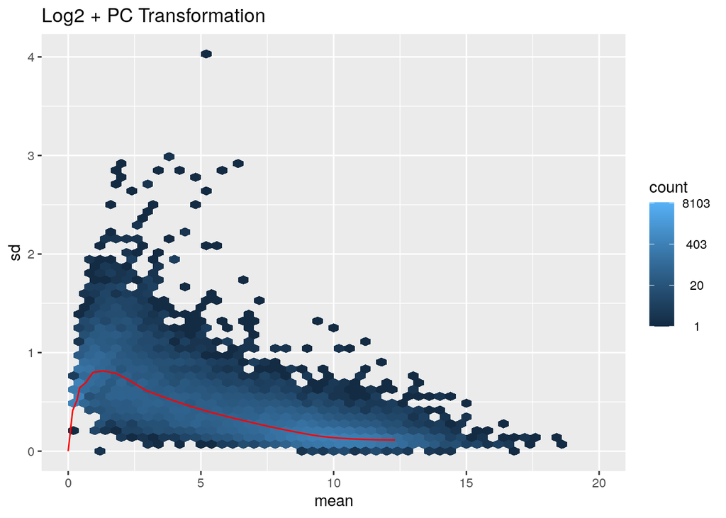

```r
log2_counts <- assay(normTransform(dds))
rld_counts <- assay(rlog(dds))



library(vsn)
library(hexbin)



## x-axis is the transformed mean not the raw mean..



log2_plt <- meanSdPlot(log2_counts, ranks=FALSE, plot=FALSE)
log2_plt$gg + ggtitle("Log2 + PC Transformation") + xlim(0,20)
```

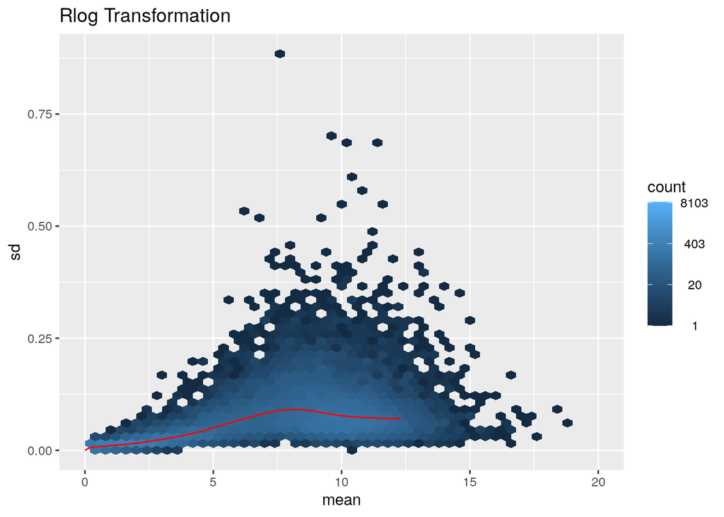

```r
rld_plt <- meanSdPlot(rld_counts, ranks=FALSE, plot=FALSE)
rld_plt$gg + ggtitle("Rlog Transformation") + xlim(0,20)
```

In both graphs, each gene is represented on the x-axis by its mean count, while the y-axis illustrates the individual count deviation from the mean. A higher sd value signifies greater variation across samples. It is also evident that there is a negative correlation in Log2 + PC transformation graph.This suggests that increased expression is associated with stabilization. To mitigate the impact of skewed data, a log transformation was applied. This transformation not only reduces skewness but also imparts a nearly normal distribution to the data, indicating high data quality.The implementation of a log transformation was necessary as an integral step in quality control to ensure the reliability of the test. The data exhibited numerous peaks characterized by substantial standard deviation, prompting the need for normalization to achieve a more accurate depiction of expression levels.

### Save Counts

Write the counts files

```r
#dir.create("/home/data")

write.table(counts, "normalised_counts.txt", sep="\t", quote = F)

write.table(log2_counts, "log2_counts.txt", sep="\t", quote = F)
```

### Sample Heatmap

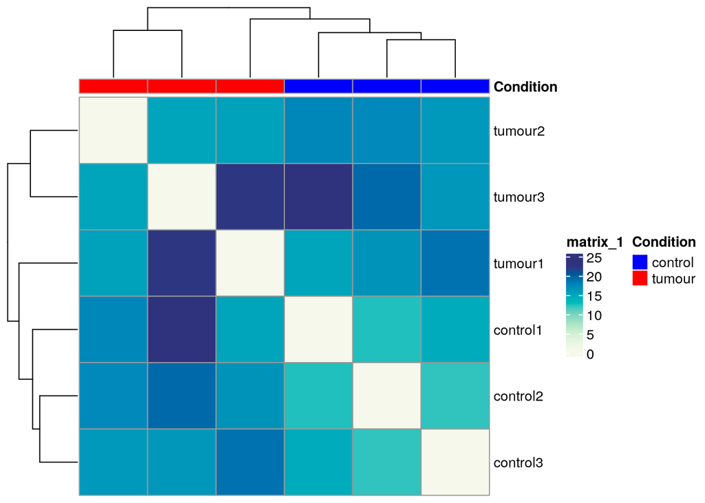

```r
## Calculate distance between samples

sampleDists <- dist(t(rld_counts))



## Place distances in matrix

sampleDistMatrix <- as.matrix(sampleDists)



## Optional, remove colnames

colnames(sampleDistMatrix) <- NULL



## create annotation dataframe

ann <- data.frame(Condition = samples$condition)



col <- c("blue", "red1")

names(col) <- c("control", "tumour")

ann_col <- list(Condition = col)

#controls are marked with blue and tumour samples are marked with red



## match annotation rownames to distance mat

rownames(ann) <- rownames(sampleDistMatrix)



pheatmap(mat=sampleDistMatrix,

         ## pass distance metric calculated to heatmap

         clustering_distance_rows=sampleDists,

         clustering_distance_cols=sampleDists,

         ## pass annotation dataframe

         annotation_col = ann,

         ## add colors

         annotation_colors = ann_col,

         ## heatmap colours

         col=hcl.colors(100,"GnBu",rev=T))
```

The heatmap allowed for the viewing of the similaries between the different samples.The tumor samples display a higher degree of similarity among themselves, while the control samples also exhibit a distinct pattern of greater similarity within their group. Notably, the control samples collectively demonstrate a higher level of similarity compared to the tumor samples, as evident from the hierarchical clustering trees on the left side of the heatmap. It is noteworthy that tumor 1 sample appears closer to the controls than the remaining tumor samples. The other two tumor samples demonstrate a closer relationship to each other, suggesting a potential association with a more advanced or evolved stage.

### PCA

PCA plots the variance explained by samples in each principal component. Typically PC1 & PC2 explain the most variation in the dataset, you should look at these first and foremost.

PCA can give you a good idea of how succesful the Differential Expression analysis will be - samples that are very close together in PC feature space will not produce as many DE genes as those that are separated by a large distance.

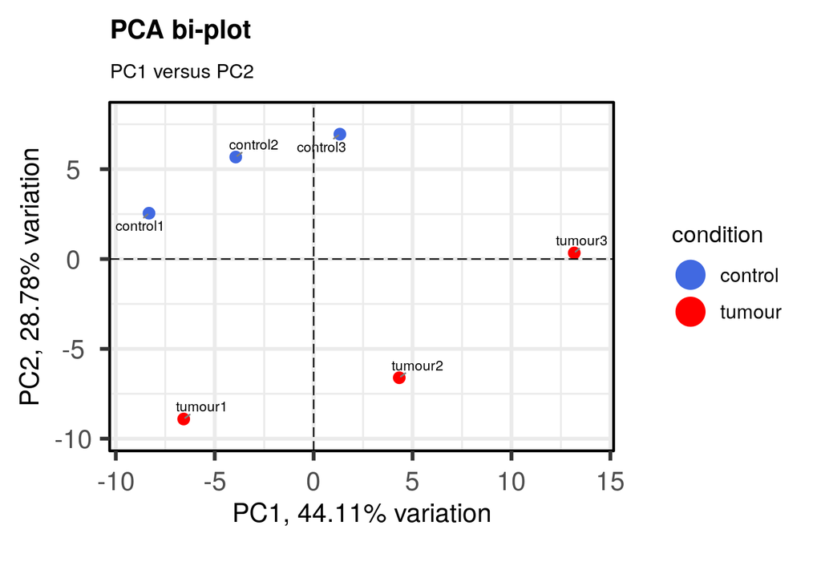

```r
p <- pca(rld_counts, metadata = samples)



biplot(p,

       colby = 'condition',

       colkey = c('control'='royalblue', 'tumour'='red1'),

       hline = 0,

       vline = 0,

       legendPosition = 'right',

       legendLabSize = 12,

       legendIconSize = 8.0,

       title = 'PCA bi-plot',

       subtitle = 'PC1 versus PC2')
```

### DESeq results()

We can extract differentially expressed genes between phenotypes of interest by using `results()` on the `DDS` object. We will apply the `apeglm` shrinkage estimator on our results. apeglm shrinks low confidence (high inter-sample variation) differentially expressed genes towards 0, producing a robust set of differentially expressed genes.

##### Set up tumour vs control:

```r
tumour_v_control <- results(dds, filterFun=ihw, alpha=0.05, c("condition", "tumour", "control")) #results() performs differential expression analysis, alpha sets the significance threshold to control the false discovery rate (FDR) at 5%.

res1 <- lfcShrink(dds=dds, res=tumour_v_control, coef=4, type="apeglm")

summary(res1)
```

```
##
## out of 21474 with nonzero total read count
## adjusted p-value < 0.05
## LFC > 0 (up)       : 269, 1.3%
## LFC < 0 (down)     : 199, 0.93%
## outliers [1]       : 0, 0%
## [1] see 'cooksCutoff' argument of ?results
## see metadata(res)$ihwResult on hypothesis weighting
```

It can be seen that there was 269 genes upregulated and there was 199 downregulated genes.

### Resusable Functions

Below are some handy functions for extracting differentially expressed genes and performing annotation of DE genes.

##### Extract Up Regulated Genes

```r
get_upregulated <- function(df){

key <- intersect(rownames(df)[which(df$log2FoldChange>=1)], rownames(df)[which(df$pvalue<=0.05)])
  results <- as.data.frame((df)[which(rownames(df) %in% key),])
return(results)
}
```

##### Extract Down Regulated genes

```r
get_downregulated <- function(df){
    key <- intersect(rownames(df)[which(df$log2FoldChange<=-1)], rownames(df)[which(df$pvalue<=0.05)])
    results <- as.data.frame((df)[which(rownames(df) %in% key),])
    return(results)
}
```

##### Annotate DE genes

```r
annotate_de_genes <- function(df){


    df$hgnc_symbol <- rownames(df)
    mart <- useMart(biomart = "ensembl", dataset = "hsapiens_gene_ensembl")
    info <- getBM(attributes=c("hgnc_symbol",

                               "ensembl_gene_id_version",

                               "chromosome_name",

                               "start_position",

                               "end_position",

                               "strand",

                               "entrezgene_description"),

                  filters = c("hgnc_symbol"),

                  values = df$hgnc_symbol,

                  mart = mart,

                  useCache=FALSE)



    tmp <- merge(df, info, by="hgnc_symbol")

    tmp$strand <- gsub("-1", "-", tmp$strand)

    tmp$strand <- gsub("1", "+", tmp$strand)

    tmp$hgnc_symbol <- make.names(tmp$hgnc_symbol, unique = T)

    tmp <- tmp[!grepl("CHR", tmp$chromosome_name),]



    output_col <- c("Gene", "Ensembl ID", "Chromosome", "Start", "Stop", "Strand", "Description", "Log2FC", "P-value", "Adj P-value")

    tmp <- subset(tmp, select=c(hgnc_symbol, ensembl_gene_id_version, chromosome_name, start_position, end_position, strand, entrezgene_description, log2FoldChange, pvalue, padj))

    colnames(tmp) <- output_col



    if(min(tmp$Log2FC) > 0){

        tmp <- tmp[order(-tmp$Log2FC),]

    }else{

        tmp <- tmp[order(tmp$Log2FC),]

    }



    return(tmp)



}
```

### Write DE results

Use the above functions to extract up/down regulated genes and annotate them using biomaRt, and write to a file. Please note that the get_(up/down)regulated function requires a dataframe as input.

```r
de_up <- get_upregulated(as.data.frame(res1))
de_down <- get_downregulated(as.data.frame(res1))
upregulated_genes <- annotate_de_genes(de_up)
downregulated_genes <- annotate_de_genes(de_down)


#confirm these worked

head(upregulated_genes)
```

```
##        Gene         Ensembl ID Chromosome    Start     Stop Strand
## 22    ID3.1  ENSG00000117318.9          1 23557926 23559501      -
## 19      ID1  ENSG00000125968.9         20 31605283 31606515      +
## 2  ADAMTS12 ENSG00000151388.11          5 33523535 33892019      -
## 41 SERPINA3 ENSG00000196136.18         14 94612384 94624055      +
## 20      ID2 ENSG00000115738.10          2  8678845  8684461      +
## 7    COL9A3 ENSG00000092758.18         20 62816244 62841159      +
##                                                  Description   Log2FC
## 22                                inhibitor of DNA binding 3 5.309228
## 19                                inhibitor of DNA binding 1 4.641088
## 2  ADAM metallopeptidase with thrombospondin type 1 motif 12 3.893075
## 41                                  serpin family A member 3 2.522209
## 20                                inhibitor of DNA binding 2 2.369897
## 7                             collagen type IX alpha 3 chain 1.988636
##         P-value  Adj P-value
## 22 6.960119e-59 6.133117e-55
## 19 9.102691e-06 7.257725e-03
## 2  2.217945e-07 2.977187e-04
## 41 1.229013e-07 3.701088e-05
## 20 1.336508e-54 4.093106e-51
## 7  1.460228e-10 2.857613e-08
```

# Results Plots

### Volcano Plot

Volcano plots are useful to show how many genes are differentially expressed in the experimental contrast of interest. Labels are optional, I have included them so you know how to use them.

> N.B Volcano plots use -log10 on the Y-axis.

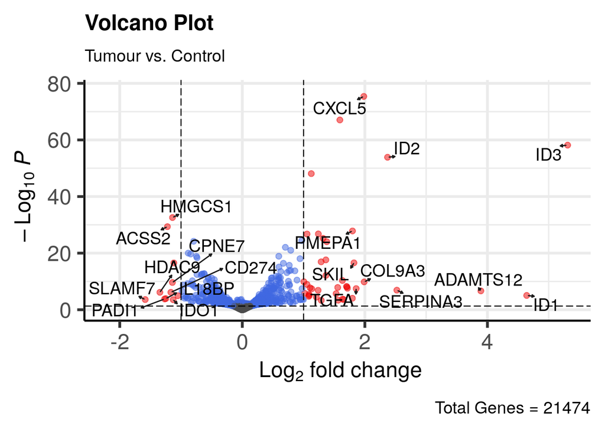

```r
## remove NA values from results

res1 <- na.omit(res1)


## calculate min/max axis values for plot (optional)

min_width <- min(res1$log2FoldChange)
max_width <- max(res1$log2FoldChange)
max_height <- -log10(min(res1[res1$pvalue>0, 5]))


## Grab top 10 up-reg genes for plot

up <- subset(res1, res1$log2FoldChange > 1 & res1$pvalue <= 0.05)
up <- up[order(-up$log2FoldChange),]
up_list <- head(rownames(up), n=10L)


## Grab top 10 down-reg genes for plot

down <- subset(res1, res1$log2FoldChange < -1 & res1$pvalue <= 0.05)
down <- down[order(down$log2FoldChange),]
down_list <- head(rownames(down), n=10L)



## place top 20 DE genes in vector (optinal...)

plot_top_20 <- c(up_list, down_list)



EnhancedVolcano(res1,

                lab=rownames(res1),

                x="log2FoldChange",

                y="pvalue",

                selectLab=plot_top_20,

                drawConnectors=TRUE,

                legendPosition = "none",

                FCcutoff=1.0,

                pCutoff=0.05,

                title="Volcano Plot",

                subtitle="Tumour vs. Control",

                caption= paste0('Total Genes = ', nrow(res1)),

                xlim=c(min_width, max_width),

                ylim=c(0, max_height))
```

### Bonus: apeglm visualised

Make a volcano plot of `tumour_v_ctrl`, the `DESeq2` results object that has not been filtered by `apeglm`.

You can see that there are genes with very large log2 FC values. As a rule of thumb, be skeptical of genes that have LFC values over +/- 10.

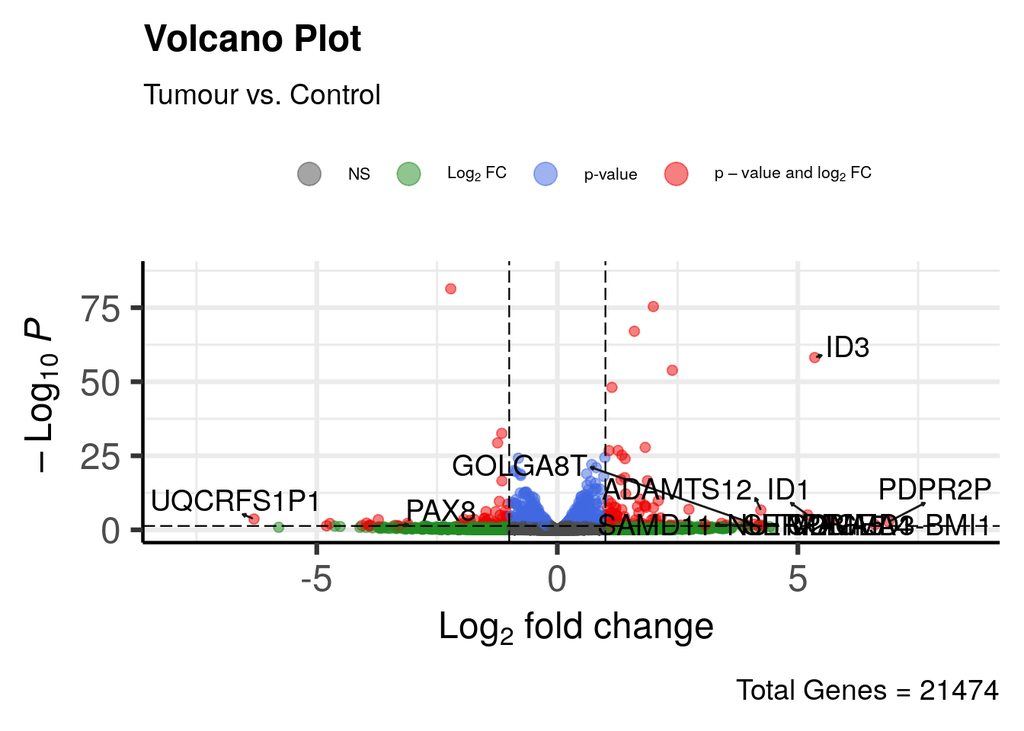

```r
res1 <- na.omit(tumour_v_control)


min_width <- min(res1$log2FoldChange)
max_width <- max(res1$log2FoldChange)
max_height <- -log10(min(res1[res1$pvalue>0, 5]))


up <- subset(res1, res1$log2FoldChange > 1 & res1$pvalue <= 0.05)
up <- up[order(-up$log2FoldChange),]
up_list <- head(rownames(up), n=10L)



down <- subset(res1, res1$log2FoldChange < -1 & res1$pvalue <= 0.05)
down <- down[order(down$log2FoldChange),]
down_list <- head(rownames(down), n=10L)



plot_top_20 <- c(up_list, down_list)
EnhancedVolcano(res1,

          lab=rownames(res1),

                    x="log2FoldChange",

                    y="pvalue",

                    selectLab=plot_top_20,

                    drawConnectors=TRUE,

                    FCcutoff=1.0,

                    pCutoff=0.05,

                    title="Volcano Plot",

                    subtitle="Tumour vs. Control",

                    legendLabSize=8,

                    caption = paste0('Total Genes = ', nrow(res1)))
```

```r
##reset res1 for heatmaps

res1 <- na.omit(res1)
```

Heatmaps are another way to show the differentially expressed genes in the experimental contrast of interest.

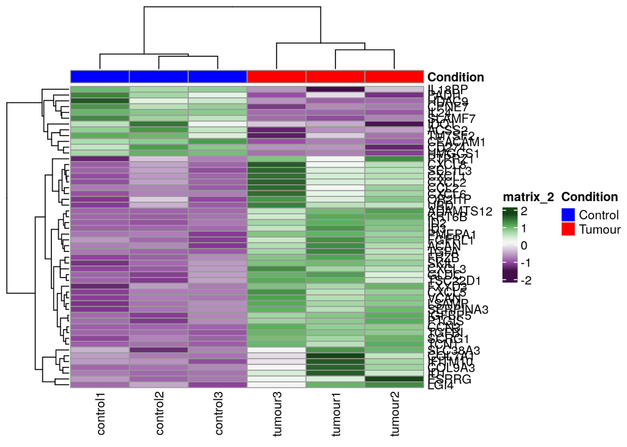

```r
# subset the counts matrix to get the Tumour and control samples

subset <- rld_counts[, 1:6]



# now select de_up, de_down, i.e DE genes that passed the filtering our function produced

up <- rownames(de_up)

down <- rownames(de_down)



# subset matrix to include only DE genes

key <- c(up, down)

subset <- subset[which(rownames(subset) %in% key),]



# scale and center the values

mat <- as.matrix(scale(t(subset), center = T))



# basic plot to check we're plotting something sensible

#pheatmap(t(mat))



# spruce it up a bit..

ann <- data.frame(Condition = c(rep("Control", 3), rep("Tumour", 3)))

rownames(ann) <- rownames(mat)

col <- c("blue", "red")

names(col) <- c("Control", "Tumour")

ann_col <- list(Condition = col)



pheatmap(t(mat),

         show_rownames = TRUE,

         annotation_col = ann,

         annotation_colors = ann_col,

         color = hcl.colors(100, "PRGn",rev=F))
```

This heatmap represent the gene expression of the upregulated and down regulated genes.The highly upregulated genes are dark green whereas the highly downregulated genes are dark purple.the genes can be categorized into two primary groups: one exhibiting upregulation in controls and downregulation in tumors from IL18BP to HMGCS, and the other showing the opposite trend, with downregulation in controls and upregulation in tumors from PTPRZ1 to LGI4.The heatmap highlights regions of substantial differential regulation across samples. For instance, genes spanning from PTPRZ1 to UBD display significant upregulation in Tumor 3, while exhibiting minimal differential expression in Tumor 1.

# Pathway Analysis

## fgsea

### Create ranked gene list

Extract the gene names and associated log2FoldChanges from our tumour vs control study to generate a ranked gene list.

```r
## convert result object to dataframe

res <- as.data.frame(res1) # lung vs control

res$hgnc_symbol <- rownames(res)



# compute summary stat

fgsea_rank <- res %>%

              dplyr::select(hgnc_symbol, log2FoldChange) %>%

              na.omit() %>%

              distinct() %>%

              group_by(hgnc_symbol) %>%

              summarize(stat=mean(log2FoldChange))



fgsea_rank
```

```
## # A tibble: 21,474 × 2
##    hgnc_symbol     stat
##    <chr>          <dbl>
##  1 ""          -0.0135
##  2 "A1BG"      -0.0707
##  3 "A1CF"       0.151
##  4 "A2M"       -0.178
##  5 "A2ML1"      2.34
##  6 "A2MP1"      0.397
##  7 "A3GALT2"   -0.00358
##  8 "A4GALT"     1.42
##  9 "A4GNT"     -0.449
## 10 "AAAS"      -0.0504
## # ℹ 21,464 more rows
```

```r
# create named list

rank <- deframe(fgsea_rank)

head(rank, 20)
```

```
##                      A1BG         A1CF          A2M        A2ML1        A2MP1
## -0.013521913 -0.070717455  0.151302767 -0.178179246  2.339741878  0.397354802
##      A3GALT2       A4GALT        A4GNT         AAAS         AACS       AACSP1
## -0.003578694  1.417910706 -0.449161265 -0.050395570 -0.240345260 -1.601524288
##        AADAC      AADACL3      AADACL4        AADAT        AAGAB         AAK1
## -0.888838934 -0.004556136  1.671566619  0.139796142 -0.191357582  0.326965135
##        AAMDC         AAMP
## -0.059535870 -0.026687365
```

### Read GMT file

```r
# read in gmt file

pathway <- gmtPathways("/home/rstudio/c6.all.v2023.2.Hs.symbols.gmt")

head(pathway, 1)
```

```
## $AKT_UP.V1_DN
##   [1] "ACKR3"    "ADGRL1"   "ADHFE1"   "ALPL"     "AMPD2"    "ANGPTL4"
##   [7] "AQP5"     "ASF1A"    "ASS1"     "AXIN2"    "BCS1L"    "BEX4"
##  [13] "BLVRB"    "BTBD2"    "C11orf71" "C1R"      "C1S"      "CAP2"
##  [19] "CAV2"     "CBS"      "CD248"    "CDC42BPA" "CDH16"    "CDPF1"
##  [25] "CELA1"    "CHAD"     "CHN2"     "CHST12"   "CNN2"     "COL17A1"
##  [31] "CSDC2"    "DNAJA3"   "DPT"      "DRAM1"    "EDARADD"  "EFEMP1"
##  [37] "EFEMP2"   "EIF4E3"   "ESR2"     "EXOSC1"   "FAH"      "FAM20C"
##  [43] "FANK1"    "FAS"      "FBXO32"   "FHOD3"    "FKBP11"   "FMO2"
##  [49] "FMO3"     "FUT10"    "FUT8"     "FXYD1"    "G6PC2"    "GALNT16"
##  [55] "GAS1"     "GATAD2B"  "GHR"      "GNA14"    "GNMT"     "GRAMD1A"
##  [61] "GSPT2"    "GSTA4"    "HEBP1"    "HIC1"     "HMGCS2"   "HPS1"
##  [67] "HTRA1"    "IBSP"     "ID3"      "IFFO1"    "IFRD2"    "IL13RA1"
##  [73] "IL17RC"   "IRS1"     "IRS2"     "ISLR"     "ITGBL1"   "ITIH5"
##  [79] "ITPKB"    "KCNK3"    "KCNN4"    "KCTD12"   "KLF2"     "KRT15"
```

[output cut: 18 more lines]

### Run fgsea

```r
# run fgsea

fgsea <- fgsea(pathways=pathway, stats=rank, nperm=1000)



fgseaResTidy <- fgsea %>%

  as_tibble() %>%

  arrange(desc(NES))



# Show in a nice table:

fgseaResTidy %>%

  dplyr::select(-leadingEdge, -ES, -nMoreExtreme) %>%

  arrange(padj) %>%

  DT::datatable()
```

|  | pathway | pval | padj | NES | size |
| --- | --- | --- | --- | --- | --- |
| 1 | HINATA_NFKB_IMMU_INF | 0.00686106346483705 | 0.6483704974271012 | 1.658343875185135 | 15 |
| 2 | PRC2_EED_DN.V1_DN | 0.006644518272425249 | 0.6483704974271012 | -1.405501331985212 | 191 |
| 3 | KRAS.AMP.LUNG_UP.V1_DN | 0.03374233128834356 | 1 | 1.342328223722504 | 123 |
| 4 | ESC_J1_UP_EARLY.V1_DN | 0.0513950073421439 | 1 | 1.274616148809429 | 166 |
| 5 | P53_DN.V2_UP | 0.0900763358778626 | 1 | 1.238478143171893 | 135 |
| 6 | RELA_DN.V1_DN | 0.1165644171779141 | 1 | 1.215994761120547 | 119 |
| 7 | WNT_UP.V1_UP | 0.1008902077151335 | 1 | 1.205515955438292 | 158 |
| 8 | PGF_UP.V1_DN | 0.102489019033675 | 1 | 1.202774426754738 | 172 |
| 9 | KRAS.LUNG_UP.V1_UP | 0.1371340523882897 | 1 | 1.193849955918219 | 116 |
| 10 | KRAS.KIDNEY_UP.V1_UP | 0.1312977099236641 | 1 | 1.186653003517431 | 135 |

[output cut: 179 more lines]

### Enrichment plots

Here, you can see examples of pathways enriched in our tumour samples, and pathways enriched in Control (i.e negative NES score)

```r
filtered_pathway <- subset(fgsea, NES > 1.3)

filtered_pathway
```

```
##                   pathway        pval      padj        ES      NES nMoreExtreme
## 1:   HINATA_NFKB_IMMU_INF 0.006861063 0.6483705 0.7655350 1.658344            3
## 2: KRAS.AMP.LUNG_UP.V1_DN 0.033742331 1.0000000 0.4252672 1.342328           21
##    size                               leadingEdge
## 1:   15      OLR1,CXCL3,CXCL2,CXCL6,IL6,CXCL8,...
## 2:  123 MC2R,CEND1,CACNA1F,GABRB1,SLC5A2,EPYC,...
```

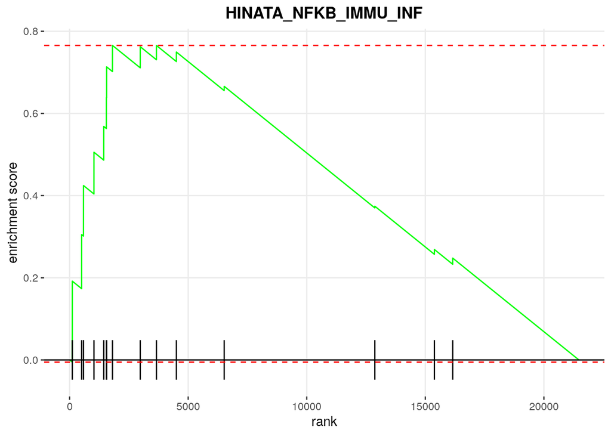

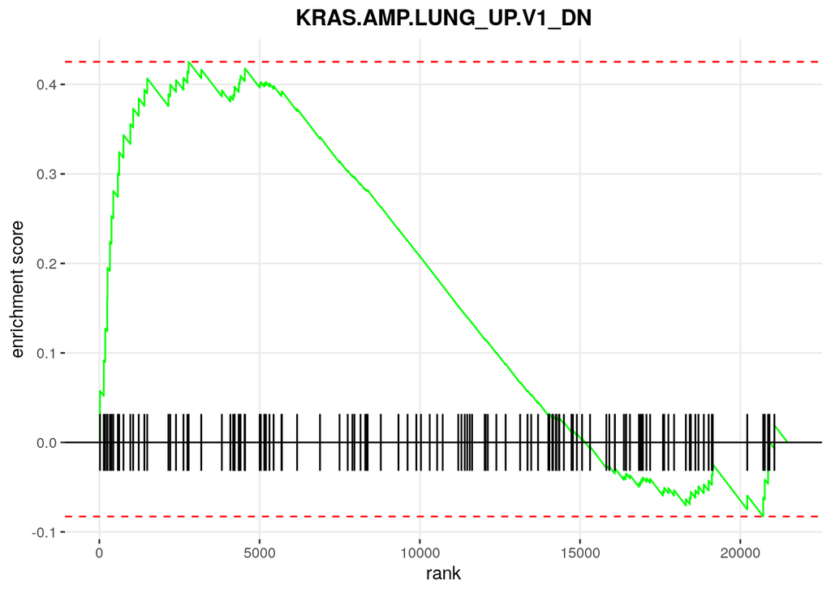

```r
filt_up <- as.vector(filtered_pathway$pathway)



for (i in filt_up){

    plt <- plotEnrichment(pathway = pathway[[i]],

    gseaParam = 1, ticksSize = 0.5, stats= rank) +

    labs(title=i) + theme(plot.title = element_text(hjust = 0.5, face="bold"))

    print(plt)

}
```

```r
filtered_pathway <- subset(fgsea, NES < -1.3)

filtered_pathway
```

```
##              pathway        pval      padj         ES       NES nMoreExtreme
## 1:    CAHOY_NEURONAL 0.054830287 1.0000000 -0.4075907 -1.325386           20
## 2: CSR_LATE_UP.V1_DN 0.017291066 1.0000000 -0.3944670 -1.349382            5
## 3: PRC2_EED_DN.V1_DN 0.006644518 0.6483705 -0.3957005 -1.405501            1
##    size                                leadingEdge
## 1:   87 SLC17A6,KCNIP4,CALN1,SLC35F4,GLRA2,NTS,...
## 2:  140  MRGPRF,TCEAL7,HMGCS1,APOL3,TOX,INSIG1,...
## 3:  191   CRYBG2,TMEM59L,MISP,KCNS1,SYN1,WFDC1,...
```

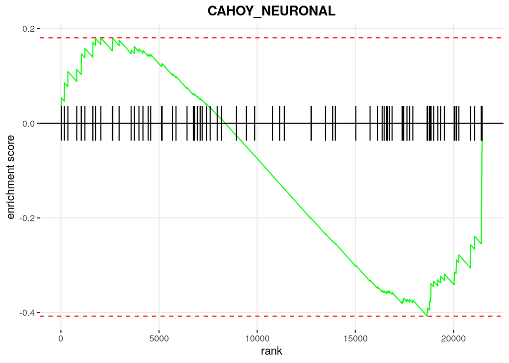

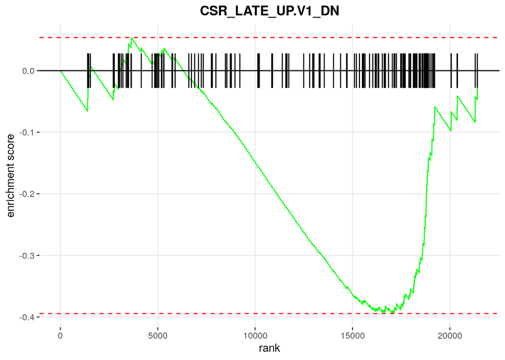

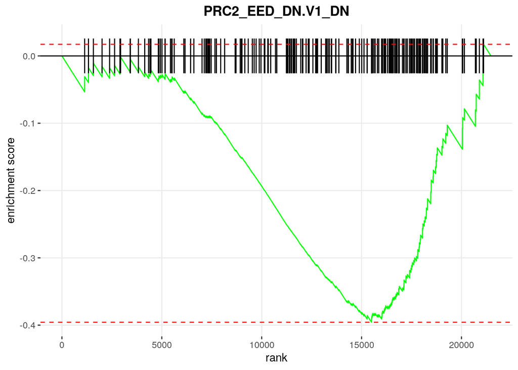

```r
filt_down <- as.vector(filtered_pathway$pathway)



for (i in filt_down){

    plt <- plotEnrichment(pathway = pathway[[i]],

    gseaParam = 1, ticksSize = 0.5, stats= rank) +

    labs(title=i) + theme(plot.title = element_text(hjust = 0.5, face="bold"))

    print(plt)

}
```

Top differentially expressed genes to known cancer biology

HINATA_NFKB_IMMU_INF:This gene set was recognised as the most differentially expressed. It is identified by the systematic name M2645, focuses on immune and inflammatory genes induced by NF-kappaB in primary keratinocytes and fibroblasts. NF-kappaB is a pivotal regulator in both normal and pathological processes, playing a context-dependent role in neoplasia. In skin, its involvement in epidermal homeostasis and the development of squamous cell carcinoma is well-established.(Hinata,K, 2003) While NF-kappaB induces proinflammatory and antiapoptotic genes in both settings, it exhibits divergent effects on growth regulatory genes. Specifically, in keratinocytes, NF-kappaB induces p21(CIP1), inhibiting the growth of both cell types. Conversely, the growth inhibitory factor (GIF) is increased by NF-kappaB in both settings but inhibits growth only in keratinocytes. These findings underscore the tissue-selective programming ability of transcription factors like NF-kappaB, driven by both differential target gene induction and the induction of common targets with varying effects based on cellular lineage.

KRAS.AMP.LUNG_UP.V1_DN:This gene set is genes that are downregulated and are linked to lung cancer. Lung cancer is a leading global cause of cancer-related deaths, often asymptomatic in early stages. The Kirsten rat sarcoma virus oncogene homolog (KRAS) is frequently mutated in non-small cell lung cancer, impacting patient survival. This information is crucial for tailored treatment, considering rapid pharmaceutical advancements. Single nucleotide polymorphisms altering let-7 micro-RNA influence cancer susceptibility. Gefitinib is used to target KRAS but it faces resistance due to direct interaction with phosphoinositide3-kinase. Atorvastatin may overcome gefitinib resistance. Focal adhesion kinase inhibitors and Heat Shock protein90 inhibition show promise against KRAS-related cancers. Phosphoinositide 3-kinase pathway inhibition and programmed cell death ligand1 blocking offer therapeutic avenues, despite challenges posed by KRAS’s complex nature. Ongoing research, including inhibitors, immunotherapy, and combinations, holds promise for overcoming this challenging disease.(Ghosh, S, 2023)

Ghosh, S., Bhuniya, T., Dey, A., Koley, M., Roy, P., Bera, A., Gol, D., Chowdhury, A., Chowdhury, R., & Sen, S. (2023). An Updated Review on KRAS Mutation in Lung Cancer (NSCLC) and Its Effects on Human Health. Applied biochemistry and biotechnology, 10.1007/s12010-023-04748-8. Advance online publication.

Chang, H. Y., Sneddon, J. B., Alizadeh, A. A., Sood, R., West, R. B., Montgomery, K., Chi, J. T., van de Rijn, M., Botstein, D., & Brown, P. O. (2004). Gene expression signature of fibroblast serum response predicts human cancer progression: similarities between tumors and wounds. PLoS biology, 2(2), E7.

Hinata, K., Gervin, A. M., Jennifer Zhang, Y., & Khavari, P. A. (2003). Divergent gene regulation and growth effects by NF-kappa B in epithelial and mesenchymal cells of human skin. Oncogene, 22(13), 1955–1964.